# El Atomo

## Números atómico y másico, y masa.

Los átomos de los distintos elementos se identifican por dos números: el **número atómico (Z)** y el **número másico (A)**.

### Número atómico y número másico

- **Número atómico** es el número de protones que tiene un átomo en el núcleo. **Z = Número de protones**
- **Número másico** es la suma de protones (Z) y neutrones (N) del núcleo. **A = Z + N**

Completa el siguiente texto:

A pesar de que en los primeros modelos el **___** se consideraba indivisible, distintos experimentos mostraron que estaba formado por partículas más pequeñas que se denominaron **___** . En la teoría de Rutherford existen **__** partículas subatómicas: el electrón, con carga**__** y masa muy pequeña, el **__**, cargado positivamente y el neutrón que no tiene **___** eléctrica; estas dos últimas partículas tienen aproximadamente la **__** masa. Mientras que los electrones se encuentran en la corteza, el protón y el neutrón se ubican en el **__**atómico.

Un átomo se identifica mediante su número atómico y su número másico, y se representa como se indica en la imagen.

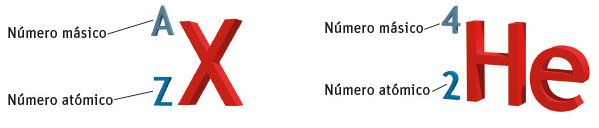

Indica el número de protones, neutrones y electrones del siguiente átomo neutro: $⁴_2He$

### Masa atómica

**Átomo de referencia**

El átomo tomado como referencia para la medida de la masa de los átomos es el carbono 12C.

Al átomo de carbono se le asigna el valor exacto de 12.

**Unidad de masa atómica (u)**

Se define como la doceava parte de la masa del átomo de carbono $^{12}_6C \qquad$ y equivale a una masa de 1,66 · 10^{–27} kg.

Así, a la masa del carbono le corresponde 12 u, y a la masa del hidrógeno, 1 u.

**Masa atómica relativa**

La masa atómica relativa es el número de veces que la masa de un átomo contiene a la unidad de masa atómica. La masa atómica relativa del carbono es 12.

Ejemplo: La masa atómica del oxígeno es de 16,0 u. Calcula su masa atómica en gramos.

Solución: La masa en gramos de un átomo de oxígeno es:$\quad (16,0u)⋅(1,66⋅10^{−24}g/u) = 2,66⋅10^{−23}$

Indica las afirmaciones que son incorrectas sobre la masa atómica.

- La masa atómica del oxígeno es de 16 u, lo cual significa que un átomo de oxígeno tiene una masa 16 veces mayor que la unidad de masa atómica.
- La masa atómica de un átomo es la masa del átomo expresada en gramos.
- La unidad de masa atómica es un átomo de carbono.

### ¿SE PUEDEN ALTERAR LOS ÁTOMOS?

**A) Quitar o añadir electrones**

**IONES** son átomos que han perdido o ganado electrones, y por tanto tienen carga eléctrica, es decir, no son neutros.

**ANIÓN** Es un átomo que ha ganado electrones. Tiene carga negativa (electrones de más).

**CATIÓN** Es un átomo que ha perdido electrones. Tiene carga positiva (electrones de menos).

**B) Quitar o añadir neutrones**

**ISÓTOPOS** son átomos de un mismo elemento que tienen el mismo número de protones (igual número atómico, Z)y distinto número de neutrones (distinto número másico, A)

Los isótopos de un elemento se diferencian en el número de neutrones que hay en sus núcleos, pero no en el número de protones.

Hay unos 300 isótoposque llamamos naturales porque se encuentran en la Tierra.

Hay 21 elementos que no tienen isótopos naturales: flúor, sodio, fósforo, cobalto, oro...

Los isótopos artificiales se obtienen en el laboratorio aumentando el número de neutrones de un átomo al bombardear sus núcleos con otras partículas que contienen neutrones.

Muchos isótopos son inestables y se desintegran fácilmente, emitiendo partículas con cierta energía o radiaciones que pueden detectarse mediante aparatos adecuados. Son los isótopos radiactivos. Se pueden emplear para tres aplicaciones fundamentalmente: como fuente de energía, en investigaciones científicas y en medicina. Los residuosque se originan en el uso de los radioisótopos son su principal inconveniente

## Isótopos y sus aplicaciones

Los isótopos son átomos de un mismo elemento que tienen el mismo número de protones (igual número atómico), pero diferente número de neutrones (distinto número másico).

Conociendo la masa atómica (A1, A2…) y la abundancia (%1, %2,…) de cada uno de los isótopos de un elemento, se puede calcular la masa media ponderada de cada elemento:

$$\frac{A_1 \dot (\%_1) + A_2 \cdot (\%_2) + ... + A_n \cdot (\%_n)}{100}$$

**Ejercicios**

a) Realiza una tabla indicando el número de partículas subatómicas para los tres isótopos del carbono: ${12}_6C,^{13}_6C ; y \; {14}_6C$

b) Calcula la masa atómica media del carbono a partir de las masas de los tres isótopos del carbono y de los porcentajes de abundancia: C-12 = 98,9 %, C-13 = 1,11 %, C-14 ≈ 0 (trazas).

**Ejercicios**

c) El cloro (Z = 17) es un elemento utilizado generalmente en la desinfección de piscinas. En la naturaleza hay dos isótopos del cloro: el Cl-35, con una abundancia del 75 %, y el Cl-37, con una abundancia del 25 %. Determina:

[output not shown]

d) El tecnecio-99 y el talio-201 son isótopos radiactivos que se utilizan como trazadores en medicina, para el estudio del músculo cardiaco. Se inyectan en el torrente sanguíneo y se hace un seguimiento del trazador para observar a qué zonas del corazón llega la sangre adecuadamente. Investiga el nombre de dicha técnica y enumera qué otros órganos del cuerpo humano pueden estudiarse así.

## La corteza atómica. Modelo de Bohr

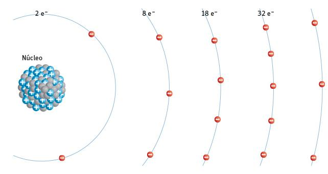

- El electrón no puede girar en cualquier órbita, sino sólo en un cierto número de órbitas estables, a determinadas distancias del núcleo. En el modelo de Rutherford se aceptaba un número infinito de órbitas.
- Cuando el electrón gira en estas órbitas no emite energía (energía constante).
- Cuando un átomo estable sufre una interacción, como puede ser el impacto de un electrón o el choque con otro átomo, uno de sus electrones puede pasar a otra órbita estable o ser arrancado del átomo.
- Cada capa, llamada también nivel de energía, tiene un número diferente de electrones. El número de electrones por nivel es $2n^2$, donde n es el número del nivel (n = 1, 2, 3,...). </font>

## Configuración electrónica

[configuración electrónica](https://sites.google.com/site/fiquizona/fisica-y-quimica-3o-eso/configuracion-electronica)

Es una forma de representar la forma en la que se distribuyen los electrones de un átomo en los distintos niveles y subniveles de energía.

### Jerarquía: Niveles, subniveles y orbitales

No todos los alumnos de Andalucía están en el mismo sitio. Los alumnos de los centros andaluces se ordenan según diferentes criterios y niveles. La primera diferenciación será según la provincia donde viva cada uno. Dentro de la provincia, según el pueblo o ciudad. Dentro de la ciudad, hay diferentes institutos y colegios y los alumnos irán a unos u otros dependiendo de su edad. En un mismo instituto, los alumnos se reparten a su vez por ciclos, según un orden creciente de edades. Dentro de cada ciclo, hay diferentes cursos. Dentro de cada curso hay alumnos que están en diferentes clases (3ºA, 3ºB, 3ºC, etc) según las asignaturas optativas que haya escogido, etc.

Vemos que hay una organización jerárquica o una serie de niveles que, siguiendo distintos criterios, caracterizan a cada alumno y ayudan a diferenciarlo administrativamente de los demás. A un alumno se le puede etiquetar como "De un centro andaluz>de Sevilla>de Gelves>del IES Gelves>de 3º de ESO>de 3ºB> alumno nº X de la lista". Este etiquetado, que podemos llamar la "configuración" del alumno lo caracteriza y sirve para distinguirlo y referirnos a él de manera específica.

Del mismo modo, los electrones que tiene un átomo no se encuentran todos en la misma órbita a la misma distancia del núcleo, sino que se encuentran repartidos en diferentes agrupaciones o niveles jerárquicos dentro del átomo, que a su vez están dentro de otros niveles. Hay varios niveles jerárquicos que hay que comprender. Reciben los siguientes nombres:

**nivel > subnivel > orbital**

### 1ª ordenación: Niveles o capas

En primer lugar, los electrones se reparten según las distintas órbitas posibles alrededor del núcleo. Cada una de estas órbitas o capas tiene un nivel de energía diferente. Los electrones se disponen en capas o niveles. Cada nivel se caracteriza por tener una energía distinta, hay 7 niveles de energía. Se les designa por números del 1 al 7 (y en cursos más avanzados, por letras)

$$n = 1, n = 2, n = 3,..., n = 7$$

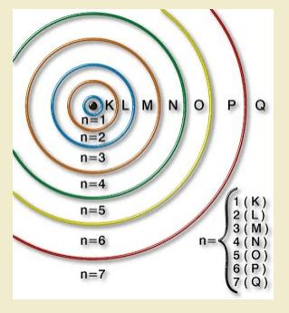

Físicamente, cada nivel de energía representa una órbita más cercana o lejana al núcleo

El número máximo de electrones que caben en cada capa o nivel viene dado por

$$2 n^2$$

Así para la capa n = 3, el número máximo de electrones que caben es 2 x 32 = 2 x 9 = 18 </font>

### 2ª ordenación: Subniveles

Además, dentro de cada nivel, hay distintos subniveles. en total hay 4 y se representan por una letra:

s, p, d, f

Un truco para recordarlas podría ser "espada fea". Estos subniveles también tienen distinta energía. El número de subniveles que puede haber en cada capa no es siempre el mismo. Depende de cada capa. El truco para saberlo es sencillo: En la capa 1 hay un subnivel (el s). En la capa 2 hay 2 subniveles (s, p). En la capa 3 hay 3 (s, p, d), y en la capa 4 hay 4 (s, p, d, f).

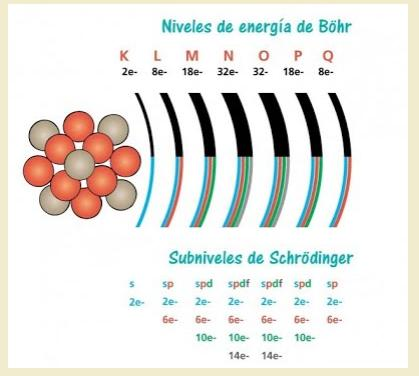

### 3ª ordenación: Orbitales

[output not shown]

**A) Orden de llenado**

El orden de llenado de los orbitales (de menor a mayor energía) se ha determinado experimentalmente, y, salvo excepciones de algunos elementos, sigue la secuencia: 1s < 2s < 2p < 3s < 3p < 4s < 3d < 4p < 5s < 4d < 5p <6s < 4f

Esta secuencia se suele representar en un diagrama llamado diagrama de Moeller:

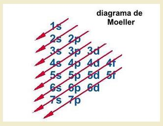

**B) Forma de escribir la configuración electrónica**

Hay que indicar los distintos niveles y subniveles del átomo que se van llenando con electrones, hasta llegar al total de electrones que tenga el átomo. Tomemos como ejemplo el caso del Helio. El Helio tiene de número atómico 2. Tiene dos protones. Por tanto, en estado neutro tendrá dos electrones. Estos dos electrones son los que tenemos que distribuir.

La forma de expresarlo es poniendo en primer lugar un número que nos dice de qué nivel de energía estamos hablando.

Detrás y en minúscula, la letra del subnivel (s, p, d f) y un exponente (o superíndice, es decir, un numerito encima a la derecha) sobre la letra del subnivel, que nos dice el número de electrones que hay en ese subnivel.